# NPT Review Conferences Dataset

Documentation

Authors

Franz Eder

University of Innsbruck

Martin Senn

University of Innsbruck

Doi

10.11587/FYVR84

Abstract

The Treaty on the Non-Proliferation of Nuclear Weapons (Nuclear Non-Proliferation Treaty, NPT) is the central regime within the global nuclear order. According to Art. VIII of the treaty, state parties have to meet in intervals of five years to review its operation. The NPT Review Conferences Dataset is a collection of 2,959 statements from these quinquennial Review Conferences (RevCon) and their respective Committees (PrepCom). It includes data from 4 RevCons (2000, 2005, 2010, 2015) and 12 PrepComs (2002, 2003, 2004, 2007, 2008, 2009, 2012, 2013, 2014, 2017, 2018, and 2019). In addition it includes data on attendance and delegation size at all RevCons and PrepComs from 1975 through 2022.

## The NPT and its review conferences

The Treaty on the Non-Proliferation of Nuclear Weapons (Nuclear Non-Proliferation Treaty, NPT) is an international regime that entered into force in 1970 (see Popp, Horovitz, and Wenger 2018) and is a central element of the so-called global nuclear order (Walker 2012) . The NPT (see the treaty text [here](https://www.un.org/disarmament/wmd/nuclear/npt/text/)) pursues three goals, which have also become known as its “three pillars”. It seeks to promote the peaceful use of nuclear energy (Art. IV and V), to prohibit the proliferation of nuclear weapons (Art. I, II, and III), and to facilitate nuclear disarmament (Art. VI).

Article VIII (3) of the treaty stipulates that parties to the treaty shall meet in intervals of five years “in order to review the operation of this Treaty with a view to assuring that the purposes of the Preamble and the provisions of the Treaty are being realised”. To prepare the substance and procedure of Review Conference, state parties meet in so-called Preparatory Committees. These quinquennial Review Conferences and their respective Preparatory Committees, in which state parties of the NPT take stock of relevant issues and discuss the ways forward, are also “seismographs for regime stability as measured by the degree of consensus and conflict among its members” (Müller 2014, 17).

After the treaty’s entry into force in 1970, state parties met for the first Review Conference in 1975. At the fifth Review Conference, which took place in 1995, NPT member states decided on the indefinite extension of the treaty (Onderco 2021). The tenth and most recent Review Conference of 2020 had to be postponed due to the COVID-19 Pandemic and was held in August 2022. The next Review Conference is scheduled for 2026.

## Data sources

The *NPT Review Conferences Dataset* is a collection of 2,959 statements from NPT Review Conferences (*RevCon*) and their respective Committees (*PrepCom*). We collected these statements from the website [Reaching Critical Will (RCW)](http://www.reachingcriticalwill.org), the disarmament program of the [Women’s International League for Peace and Freedom](http://www.wilpf.org/). In addition, we double-checked these statements with the official websites of the NPT Review Conferences and added statements that were missing. 852 of the statements were delivered at the Review Conferences of 2000, 2005, 2010, and 2015 (see Table 1). Statements of the most recent 2022 Review Conference will be added to the dataset in a next and updated version.

Table 1: Sources of Review Conferences statements

| Events | Sources |
| --- | --- |
| RevCon 2000 | http://www.reachingcriticalwill.org/disarmament-fora/npt/2000/statements |
| RevCon 2005 | http://www.reachingcriticalwill.org/disarmament-fora/npt/2005/statements |
|  | https://www.un.org/en/conf/npt/2005/statements.html |
| RevCon 2010 | http://www.reachingcriticalwill.org/disarmament-fora/npt/2010/statements |
|  | https://www.un.org/en/conf/npt/2010/ |
| RevCon 2015 | http://www.reachingcriticalwill.org/disarmament-fora/npt/2015/statements |
|  | https://www.un.org/en/conf/npt/2015/ |

2,107 statements were delivered at the Preparatory Committee meetings of 2002, 2003, 2004, 2007, 2008, 2009, 2012, 2013, 2014, 2017, 2018, and 2019 (see Table 2).

Table 2: Sources of Preparatory Committee statements

| Events | Sources |
| --- | --- |
| PrepCom 2002 | http://www.reachingcriticalwill.org/disarmament-fora/npt/2002/statements |
| PrepCom 2003 | http://www.reachingcriticalwill.org/disarmament-fora/npt/2003/statements |
| PrepCom 2004 | http://www.reachingcriticalwill.org/disarmament-fora/npt/2004/statements |
| PrepCom 2007 | http://www.reachingcriticalwill.org/disarmament-fora/npt/2007/statements |
| PrepCom 2008 | http://www.reachingcriticalwill.org/disarmament-fora/npt/2008/statements |
| PrepCom 2009 | http://www.reachingcriticalwill.org/disarmament-fora/npt/2009/statements |
| PrepCom 2012 | http://www.reachingcriticalwill.org/disarmament-fora/npt/2012/statements |
| PrepCom 2013 | http://www.reachingcriticalwill.org/disarmament-fora/npt/2013/statements |
| PrepCom 2014 | http://www.reachingcriticalwill.org/disarmament-fora/npt/2014/statements |
| PrepCom 2017 | http://www.reachingcriticalwill.org/disarmament-fora/npt/2017/statements |
| PrepCom 2018 | http://reachingcriticalwill.org/disarmament-fora/npt/2018/statements |
| PrepCom 2019 | http://reachingcriticalwill.org/disarmament-fora/npt/2019/statements |

Of the overall 2,959 statements, 364 statements were delivered in a language other than English (e.g., Russian, French, Arabic). We translated these documents into English using [Google Translate](https://translate.google.com/).

## Dataset details

This dataset comprises nine files:

- this documentation (`10817_mr_en_v1_0.html` and `10817_mr_en_v1_0.pdf`),
- the collection of statments as txt-files (`10817_da01_en_v1_0.zip`),
- a list of all participants (`10817_om_en_v1_0.zip`),
- an RStudio project file (`10817_sx01_en_v1_0.Rproj`),
- an R-script for extracting the `10817_da01_en_v1_0.zip`-file and importing and manipulating the dataset (`10817_sx02_en_v1_0.R`),
- the dataset as a csv-file (`10817_da02_en_v1_0.csv`),
- the attendence list by groups (i.e., states, IGOs, NGOs, observers) to the NPT Review Conferences from 1975 - 2022 (`10817_da03_en_v1_0.csv`),
- the list of delegations to the NPT Review Conferences from 1975 - 2022 (`10817_da04_en_v1_0.csv`).

### 10817_da01_en_v1_0.zip

`10817_da01_en_v1_0.zip` comprises the 2,959 statements as txt-files. The file naming convention for these files is as follows:

Table 3: File naming convention of txt-files

| element | explanation |
| --- | --- |
| `event` | Either `RevCon` for statements in Review Conferences or `PrepCom` for statements in Preparatory Committee meetings. |
| `year` | Year in which the statement was issued. |
| `committee` | Committee in which the statement was issued. `NA` if not available. |
| `actor` | Actor (e.g., Algeria, France, etc.) issuing the statement. |
| `month` | Month in which the statement was issued. |
| `day` | Day on which the statement was issued. |
| `count_statement` | Number of statements per day. |

### 10817_om_en_v1_0.zip

`10817_om_en_v1_0.zip` comprises a collection of txt-files with the list of all participants in these events. We grouped these participants into the following groups:

Table 4: List of actors

| actors | explanation |
| --- | --- |
| `States` | Official states. |
| `State-groups` | Group of states that formed coliations and issued statements on behalf of these groups (e.g., African Group, Central Asian states, etc.). |
| `IGOs` | International Governmental Organizations (e.g., African Union, ASEAN, etc.) |
| `NGOs` | Non-governmental Organizations (e.g., Arms Control Association, Greenpeace, etc.) |
| `others` | Actors issuing statements that do not belong to other groups (e.g., Acting President, Chair PrepCom, etc.) |

### 10817_sx01_en_v1_0.Rproj

`10817_sx01_en_v1_0.Rproj` is the RStudio project file that users should copy to the folder of the r-scripts to ensure that the relative path to the files work as supposed.

### 10817_da02_en_v1_0.csv

`10817_da02_en_v1_0.csv` is a dataframe comprising all statements including meta-data, that can be used for statistical analysis. The structure of this dataframe looks as follows:

```
'data.frame':   2959 obs. of  12 variables:
 $ doc_id         : chr  "PrepCom_2002_NA_Algeria_04_08_01.txt" "PrepCom_2002_NA_Algeria_04_11_01.txt" "PrepCom_2002_NA_Algeria_04_15_01.txt" "PrepCom_2002_NA_Algeria_04_16_01.txt" ...
 $ text           : chr  "Mister President,\n\nI am particularly pleased to see you chairing the work of the first session\nof the Prepar"| __truncated__ "Mister President,\n\nThe Algerian delegation wishes to comment on the\ndebate issue on nuclear disarmament\n\nM"| __truncated__ "Intervention\nMe…
 $ event          : Factor w/ 2 levels "PrepCom","RevCon": 1 1 1 1 1 1 1 1 1 1 ...
 $ year           : int  2002 2002 2002 2002 2002 2002 2002 2002 2002 2002 ...
 $ committee      : Factor w/ 13 levels "C1","C2","C3",..: NA NA NA NA NA NA NA NA NA NA ...
 $ actor          : Factor w/ 304 levels "ABAAC","Abolition2000",..: 11 11 11 11 13 15 19 26 26 28 ...
 $ month          : int  4 4 4 4 4 4 4 4 4 4 ...
 $ day            : int  8 11 15 16 17 9 8 8 16 9 ...
 $ count_statement: int  1 1 1 1 1 1 1 1 1 1 ...
 $ date           : chr  "2002-04-08" "2002-04-11" "2002-04-15" "2002-04-16" ...
 $ quarter        : int  2 2 2 2 2 2 2 2 2 2 ...
 $ type           : Factor w/ 5 levels "Group","IGO",..: 5 5 5 5 3 5 5 5 5 5 ...
```

Table 5: List of variables

| variable | explanation |
| --- | --- |
| `doc_id` | Character variable. Unique id of the statement (i.e., the name of the respective txt-file). |
| `text` | Character variable. Text of the statement. |
| `event` | Factor variable. Either `RevCon` for statements from Review Conferences or `PrepCom` for statements from Preparatory Committee meetings. |
| `year` | Integer variable. Year the statement was issued. |
| `committee` | Factor variable. Committee, where the statement was issued. `NA` if not available. |
| `actor` | Factor varibale. Actor (e.g., Algeria, France, etc.) issuing the statement. |
| `month` | Integer variable. Month the statement was issued. |
| `day` | Integer variable. Day the statement was issued. |
| `count_statement` | Number of statements per day. |
| `date` | Character variable. Date the statement was issued |
| `quarter` | Integer variable. Quarter, the statement was issued |
| `type` | Factor varibale. Type of actor (i.e., state, state-group, IGOs, NGOs, and others) issuing a statement. |

### 10817_da03_en_v1_0.csv

`10817_da03_en_v1_0.csv` is a dataframe comprising the collection of NPT Review Conference attendances by groups (i.e., parties, states, IGOs, NGOs, and observers) from 1975 through 2022.

```
'data.frame':   50 obs. of  3 variables:
 $ type : Factor w/ 5 levels "IGOs","NGOs",..: 4 4 4 4 4 4 4 4 4 4 ...
 $ year : Factor w/ 10 levels "1975","1980",..: 1 2 3 4 5 6 7 8 9 10 ...
 $ count: int  91 112 131 140 178 188 189 190 191 191 ...
```

This dataframe has three variables which are named as follows:

Table 6: List of variables for attendance dataset

[output not shown]

### 10817_da04_en_v1_0.csv

`10817_da04_en_v1_0.csv` lists the delegations size of states during the NPT Review Conferences from 1975 through 2022.

```
'data.frame':   1900 obs. of  4 variables:
 $ state: Factor w/ 189 levels "Afghanistan",..: 1 1 1 1 1 1 1 1 1 1 ...
 $ year : Factor w/ 10 levels "1975","1980",..: 1 2 3 4 5 6 7 8 9 10 ...
 $ size : int  0 0 1 0 3 0 3 3 3 0 ...
 $ iso3c: Factor w/ 189 levels "AFG","AGO","ALB",..: 1 1 1 1 1 1 1 1 1 1 ...
```

Table 7: List of variables for delegations dataset

| variable | explanation |
| --- | --- |
| `state` | Factor variable. States attending the NPT Review conference in a given year. |
| `year` | Factor variable. Year of NPT Review conference. |
| `size` | Integer variable. Total number of members per delegation in a given year. |
| `iso3c` | Factor variable. Iso3c country codes of states. |

## Descriptive analysis of the dataset

Statements of states vs. NGOs during NPT Review conferernces (`10817_da02_en_v1_0.csv`):

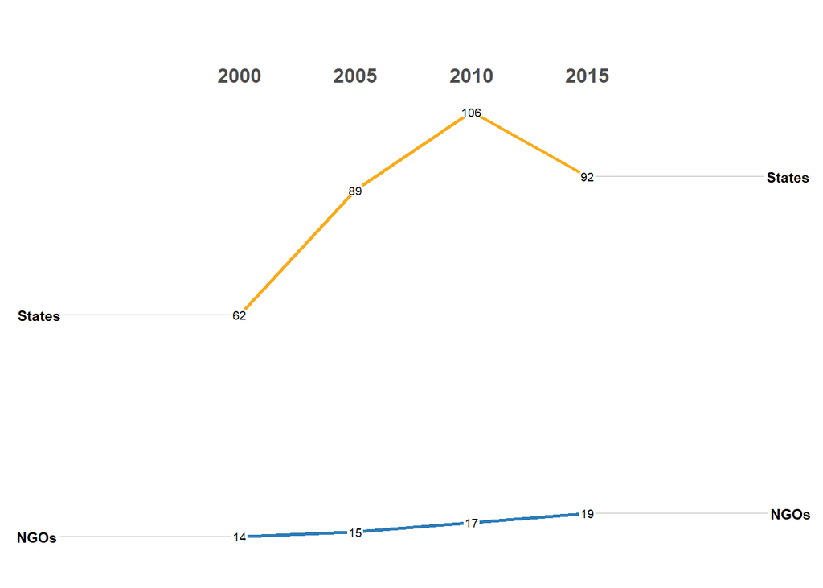

Statements of states vs. NGOs during NPT Prepartory Committee meetings (`10817_da02_en_v1_0.csv`):

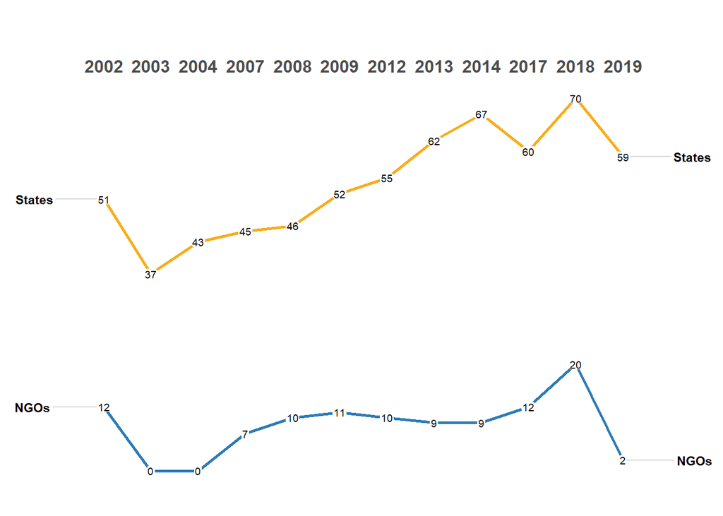

Attendance per groups during NPT Review conferences from 1975 through 2022 (`10817_da03_en_v1_0.csv`):

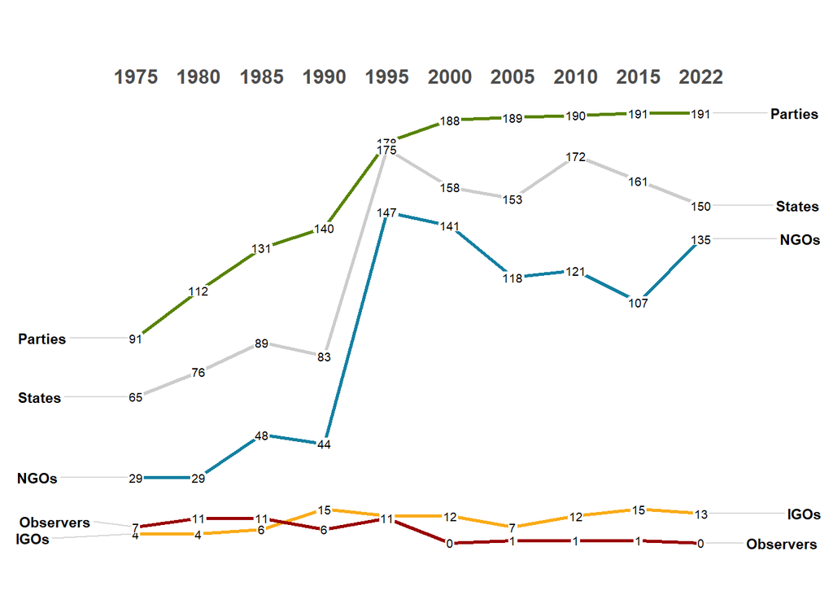

P5 delegations’ size during NPT Review conferences from 1975 through 2022 (`10817_da04_en_v1_0.csv`):

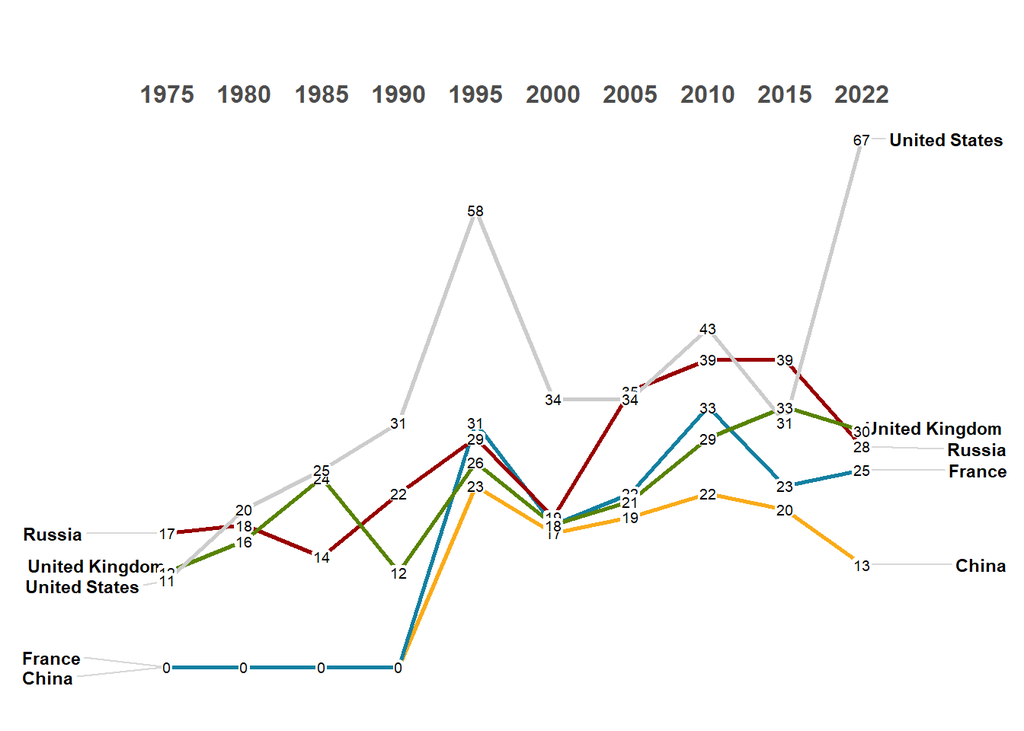

## Suggested Citation

Eder, Franz; Senn, Martin, 2023, “The Treaty on the Non-Proliferation of Nuclear Weapons (NPT) Review Conferences Dataset (SUF edition)”, https://doi.org/10.11587/FYVR84, *AUSSDA*, V1.

## Licence

NPT Review Conferences Dataset - Documentation by Franz Eder and Martin Senn (2023) is licensed under a [Creative Commons Attribution 4.0 International Licence](https://creativecommons.org/licenses/by/4.0/).”

## References

Müller, Harald. 2014. “The NPT Review Conferences.” In *The Nuclear Nonproliferation Regime at a Crossroads*, edited by Emily B. Landau and Azriel Bermant. Tel Aviv: Institute for National Security Studies.

Onderco, Michal. 2021. *Networked Nonproliferation*. Stanford, CA: Stanford University Press.

Popp, Roland, Liviu Horovitz, and Andreas Wenger. 2018. *Negotiating the Nuclear Non-Proliferation Treaty*. London: Routledge.

Walker, William. 2012. *A Perpetual Menace*. London: Routledge.